# Manejo de datos con R (I): the tidyverse way

# Tidy data en formato *LONG*

- Es importante aprender a pasar de datos WIDE a LONG y viceversa
- Con el pkg tidyr es sencillo pero …

De wide a LONG format con … `tidyr::pivot_longer()`

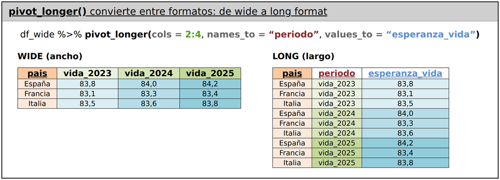

Tarea: convierte “df_wide” a formato LARGO

- Tarea
- Pistas
- Solución

Aquí tienes un df en formato ANCHO, pásalo a formato LARGO

```r
df_wide <- data.frame(pais = c("España", "Francia", "Italia"),
                      vida_2023 = c(83.8, 83.1, 83.5),
                      vida_2024 = c(84.0, 83.3, 83.6),
                      vida_2025 = c(84.2, 83.4, 83.8) )
```

Está en formato ancho:

```r
gt::gt(df_wide)
```

| pais | vida_2023 | vida_2024 | vida_2025 |
| --- | --- | --- | --- |
| España | 83.8 | 84.0 | 84.2 |
| Francia | 83.1 | 83.3 | 83.4 |
| Italia | 83.5 | 83.6 | 83.8 |

Lo quiero en formato largo:

```r
gt::gt(df_long)
```

| pais | periodo | esperanza_vida |
| --- | --- | --- |
| España | vida_2023 | 83.8 |
| España | vida_2024 | 84.0 |
| España | vida_2025 | 84.2 |
| Francia | vida_2023 | 83.1 |
| Francia | vida_2024 | 83.3 |
| Francia | vida_2025 | 83.4 |
| Italia | vida_2023 | 83.5 |
| Italia | vida_2024 | 83.6 |
| Italia | vida_2025 | 83.8 |

- Te ayudará visualizar `df_wide` y ver que columnas contienen valores de la misma variable
- Tienes que usar `tidyr::pivot_longer()` y en su primer argumento le tienes que decir que columnas hay que convertir a formato “largo”

El df original en formato ancho

| pais | vida_2023 | vida_2024 | vida_2025 |
| --- | --- | --- | --- |
| España | 83.8 | 84.0 | 84.2 |
| Francia | 83.1 | 83.3 | 83.4 |
| Italia | 83.5 | 83.6 | 83.8 |

```r
#- la función pivot_longer() transforma los datos de formato ancho(wide) a formato largo(long)
df_long <- df_wide %>%
             tidyr::pivot_longer(cols = 2:4,
                                 names_to = "periodo",
                                 values_to = "esperanza_vida")
gt::gt(df_long)
```

| pais | periodo | esperanza_vida |
| --- | --- | --- |
| España | vida_2023 | 83.8 |
| España | vida_2024 | 84.0 |
| España | vida_2025 | 84.2 |
| Francia | vida_2023 | 83.1 |
| Francia | vida_2024 | 83.3 |
| Francia | vida_2025 | 83.4 |
| Italia | vida_2023 | 83.5 |
| Italia | vida_2024 | 83.6 |
| Italia | vida_2025 | 83.8 |

De long a WIDE format con `tidyr::pivot_wider()`

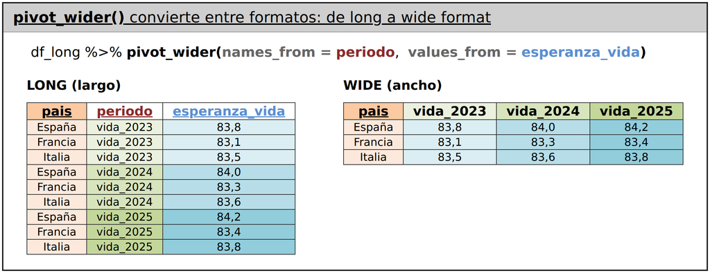

¿Por qué querríamos convertirlo a formato ANCHO?

- Para **presentar los datos en una tabla**: el formato ancho es más fácil de leer por las personas
- Porque **algunas funciones y programas** (por ejemplo Excel) esperan los datos en formato ancho

Tarea: convierte “df_long” a formato ANCHO

- Tarea
- Pistas
- Solución
- `df_long` está en formato LARGO, pásalo a formato ANCHO
- Tienes que distribuir los datos de esperanza de vida en columnas: una columna para cada año

Está en formato largo:

```r
gt::gt(df_long)
```

| pais | periodo | esperanza_vida |
| --- | --- | --- |
| España | vida_2023 | 83.8 |
| España | vida_2024 | 84.0 |
| España | vida_2025 | 84.2 |
| Francia | vida_2023 | 83.1 |
| Francia | vida_2024 | 83.3 |
| Francia | vida_2025 | 83.4 |
| Italia | vida_2023 | 83.5 |
| Italia | vida_2024 | 83.6 |
| Italia | vida_2025 | 83.8 |

Lo quiero en formato ancho: (con **una columna para cada año**)

| pais | vida_2023 | vida_2024 | vida_2025 |
| --- | --- | --- | --- |
| España | 83.8 | 84.0 | 84.2 |
| Francia | 83.1 | 83.3 | 83.4 |
| Italia | 83.5 | 83.6 | 83.8 |

- Tienes que usar `tidyr::pivot_wider()`
- En el argumento `values_from` le tienes que decir **qué columna** quieres que sus valores se distribuyan entre varias columnas
- En el argumento `names_from` le tienes que decir **qué columna** quieres que sus valores aparezcan como los títulos de las nuevas columnas que se crearán

El df en formato largo:

```r
gt::gt(df_long)
```

| pais | periodo | esperanza_vida |
| --- | --- | --- |
| España | vida_2023 | 83.8 |
| España | vida_2024 | 84.0 |
| España | vida_2025 | 84.2 |
| Francia | vida_2023 | 83.1 |
| Francia | vida_2024 | 83.3 |
| Francia | vida_2025 | 83.4 |
| Italia | vida_2023 | 83.5 |
| Italia | vida_2024 | 83.6 |
| Italia | vida_2025 | 83.8 |

```r
df_wide2 <- df_long %>%
              tidyr::pivot_wider(values_from = esperanza_vida,
                                 names_from = periodo)
```

```r
gt::gt(df_wide2)
```

| pais | vida_2023 | vida_2024 | vida_2025 |
| --- | --- | --- | --- |
| España | 83.8 | 84.0 | 84.2 |
| Francia | 83.1 | 83.3 | 83.4 |
| Italia | 83.5 | 83.6 | 83.8 |

# Extensiones

- Otra tarea más de `pivot_wider()`
- Dos funciones más de `tidyr`: `separate()` y `unite()`

Tarea: convierte `OTRA VEZ` “df_long” a formato ANCHO

- Tarea
- Pistas
- Solución
- `df_long` está en formato LARGO, pásalo a formato ANCHO
- Tienes que distribuir los datos de esperanza de vida en columnas: **`PERO`** esta vez quiero que haya una columna para cada país (España, Francia, …)

Está en formato largo:

```r
gt::gt(df_long)
```

| pais | periodo | esperanza_vida |
| --- | --- | --- |
| España | vida_2023 | 83.8 |
| España | vida_2024 | 84.0 |
| España | vida_2025 | 84.2 |
| Francia | vida_2023 | 83.1 |
| Francia | vida_2024 | 83.3 |
| Francia | vida_2025 | 83.4 |
| Italia | vida_2023 | 83.5 |
| Italia | vida_2024 | 83.6 |
| Italia | vida_2025 | 83.8 |

Lo quiero en formato ancho:

(con **una columna para cada PAÍS**)

| periodo | España | Francia | Italia |
| --- | --- | --- | --- |
| vida_2023 | 83.8 | 83.1 | 83.5 |
| vida_2024 | 84.0 | 83.3 | 83.6 |
| vida_2025 | 84.2 | 83.4 | 83.8 |

- Igual que en la tarea anterior: `tidyr::pivot_wider()` con sus argumentos `values_from` y `names_from`
- PERO, CUIDADO!!! piensa bien **qué columna** tiene que ir ahora en `names_from`

```r
df_wide2 <- df_long %>%
              tidyr::pivot_wider(values_from = esperanza_vida,
                                 names_from = pais)
```

```r
gt::gt(df_wide2)
```

| periodo | España | Francia | Italia |
| --- | --- | --- | --- |
| vida_2023 | 83.8 | 83.1 | 83.5 |
| vida_2024 | 84.0 | 83.3 | 83.6 |
| vida_2025 | 84.2 | 83.4 | 83.8 |

las funciones `separate()` y `unite()`

- El paquete *tidyr* tiene muchas funciones. Veremos dos: *separate()* y *unite()*
- `separate()` y `unite()` nos facilitarán poder separar y unir columnas
- Por ejemplo, fíjate en el siguiente dataframe: ¿es **tidy**?

| personajes | year |
| --- | --- |
| Pedro Navaja | 1978 |
| Bob Dylan | 1941 |
| Peter Pan | 1904 |

Tarea: Utilizando tidyr::separate()

- Tarea
- Pistas
- Solución
- Separa la columna `personajes` en dos columnas: `nombre` y `apellido`

```r
df <- data.frame( personajes = c("Pedro Navaja", "Bob Dylan", "Peter Pan"),
                  year  = c(1978, 1941, 1904) )
gt::gt(df)
```

| personajes | year |
| --- | --- |
| Pedro Navaja | 1978 |
| Bob Dylan | 1941 |
| Peter Pan | 1904 |

- Has de usar `tidyr::separate()`
- Tendrás que darle los valores de 3 argumentos: `col`, `into` y `sep`
  - en el argumento `col` tienes que decir **qué columna** quieres separar
  - en `into` tienes que decir **qué nombres** quieres que tengan las nuevas columnas
  - en `sep` tienes que decir **qué caracter** separa los dos elementos

```r
df_1 <- df %>%
  tidyr::separate(col = personajes,
                  into = c("nombre", "apellido"),
                  sep = " ")
```

```r
gt::gt(df)
```

| personajes | year |
| --- | --- |
| Pedro Navaja | 1978 |
| Bob Dylan | 1941 |
| Peter Pan | 1904 |

```r
gt::gt(df_1)
```

| nombre | apellido | year |
| --- | --- | --- |
| Pedro | Navaja | 1978 |
| Bob | Dylan | 1941 |
| Peter | Pan | 1904 |

Tarea: Utilizando tidyr::unite()

- Tarea
- Pistas
- Solución
- Unir las columnas `nombre` y `apellido` en una sola columna

| nombre | apellido | year |
| --- | --- | --- |
| Pedro | Navaja | 1978 |
| Bob | Dylan | 1941 |
| Peter | Pan | 1904 |

- Has de usar `tidyr::unite()`
- Tendrás que darle los valores de “3” argumentos:
  - en el argumento `col` tienes que decir **el nombre** de la nueva columna que se va a crear
  - después tienes que decir qué columnas quieres unir
  - en `sep` tienes que decir **qué carácter** separará los dos elementos que vamos a unir

```r
df_2 <- df %>%
       unite(col = nombre_y_apellido,
             c(apellido, nombre),
             sep = ", ")
```

```r
gt::gt(df)
```

| nombre | apellido | year |
| --- | --- | --- |
| Pedro | Navaja | 1978 |
| Bob | Dylan | 1941 |
| Peter | Pan | 1904 |

```r
gt::gt(df_2)
```

| nombre_y_apellido | year |
| --- | --- |
| Navaja, Pedro | 1978 |
| Dylan, Bob | 1941 |
| Pan, Peter | 1904 |